# Compare CellRanger vs scUTRquant HVGs

Mervin Fansler

23 August 2021

# Purpose

This document compares the sets of highest-variance genes across CellRanger and scUTRquant gene UMI counts. Currently, the clusters are not in perfect agreement and so this is being examined in order to determine if the sets of genes being selected are playing a significant role.

# Initialization

## Libraries

```r
library(magrittr)
library(tidyverse)
library(cowplot)
library(Matrix)
library(HDF5Array)
library(SingleCellExperiment)
library(scran)
```

## Parameters

```r
set.seed(20210818)
BiocParallel::register(BiocParallel::MulticoreParam(12))
```

## Functions

```r
get_pc_df <- function (sce_x, sce_y, pc="PC1",
                        label_x="CellRanger", label_y="scUTRquant") {
  df_rot_x <- reducedDim(sce_x, "PCA") %>%
    attr("rotation") %>% `[`(,pc) %>%
    enframe("gene", label_x)
  df_rot_y <- reducedDim(sce_y, "PCA") %>%
    attr("rotation") %>% `[`(,pc) %>%
    enframe("gene", label_y)
  full_join(df_rot_x, df_rot_y, by="gene") %>%
    mutate(across(where(is.numeric), coalesce, 0))
}

plot_weights_compare <- function (df) {
  max_abs_val <- max(abs(as.matrix(df[,-1])))
  ggplot(df, aes(x=CellRanger, y=scUTRquant)) +
    geom_abline(slope=c(1,-1),
                intercept=c(0,0), linetype='dashed') +
    geom_abline(slope=c(1,1,-1,-1),
                intercept=c(-0.05, 0.05, -0.05, 0.05),
                linetype='dashed', color='lightgrey') +
    geom_point(size=1, alpha=0.8, pch=16) +
    coord_cartesian(xlim=c(-max_abs_val, max_abs_val),
                    ylim=c(-max_abs_val, max_abs_val)) +
    theme_bw()
}
```

# Data

## Loading

```r
df_counts_all <- readRDS("data/sce/processed/df_counts.all_genes.pca.Rds")
```

## Preprocessing

### Extract PC Dataframes

```r
df_pcs <- df_counts_all %>%
  transmute(sample_id,
            PC1=map2(sce_10x, sce_sq, get_pc_df, pc="PC1"),
            PC2=map2(sce_10x, sce_sq, get_pc_df, pc="PC2"))
```

# Analysis

## Plot PC1 Weights

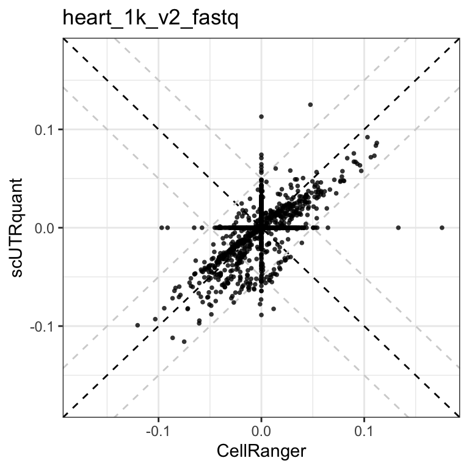

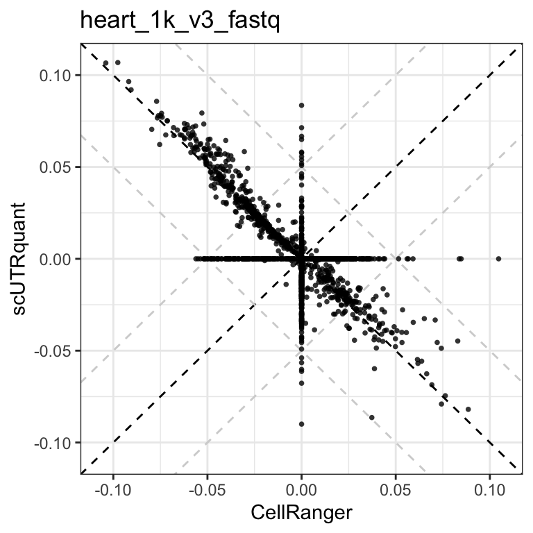

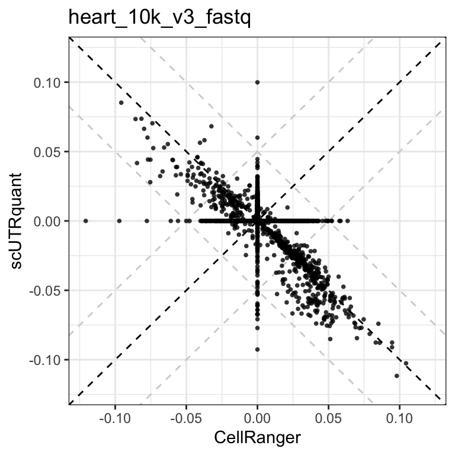

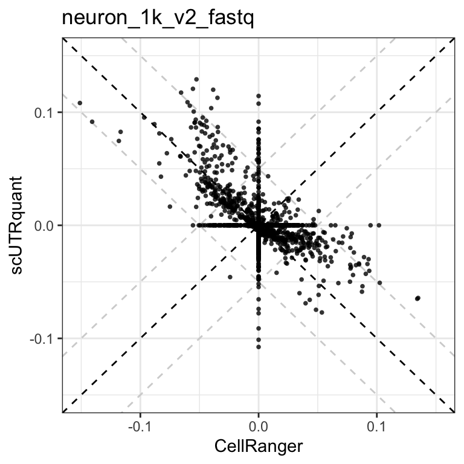

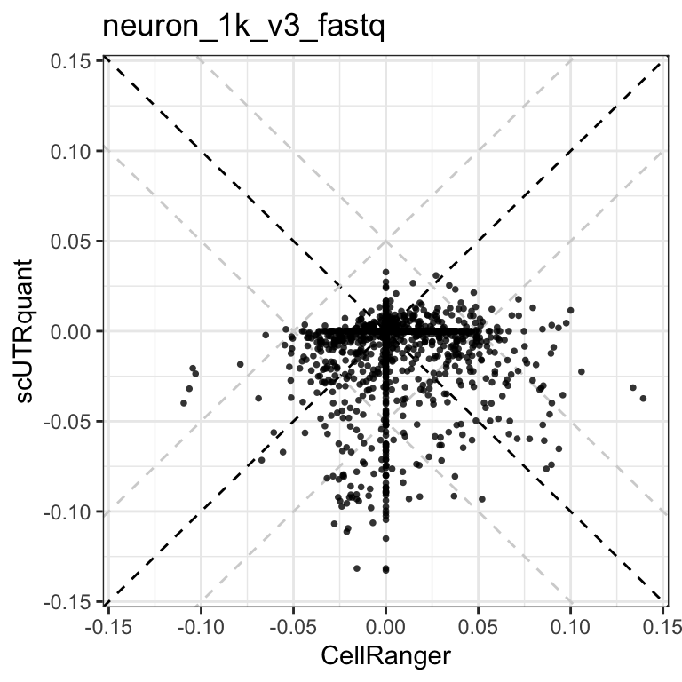

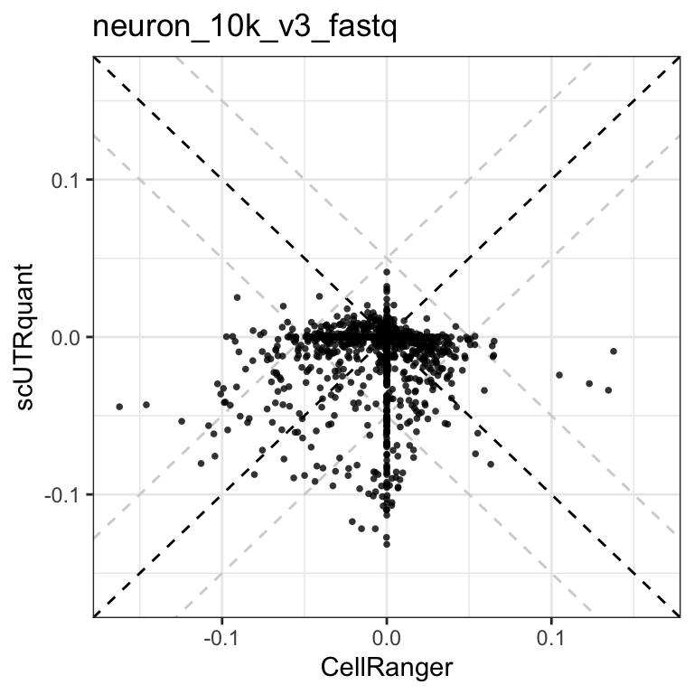

```r
df_pcs %>%
  transmute(sample_id, g=map(PC1, plot_weights_compare)) %>%
  deframe() %>% {
    for (id in names(.)) {
      ## print locally in this document
      print(.[[id]] + ggtitle(id))

      ## save to PDFs
      # ggsave(sprintf("output/supplement/sup2-pca-compare-%s.pdf", id),
      #        .[[id]], width=5, height=4, dpi=300)
    }
  }
```

### List Genes

```r
df_pcs %>%
  transmute(sample_id, g=map(PC1, function (df) {
    df %>%
      #filter(CellRanger == 0 | scUTRquant == 0 | abs(CellRanger - scUTRquant) > 0.05) %>%
      filter(abs(CellRanger - scUTRquant) > 0.1) %>%
      pull(gene)
  }))
```

```
## # A tibble: 6 x 2
##   sample_id           g
##   <chr>               <list>
## 1 heart_1k_v2_fastq   <chr [3]>
## 2 heart_1k_v3_fastq   <chr [94]>
## 3 heart_10k_v3_fastq  <chr [93]>
## 4 neuron_1k_v2_fastq  <chr [90]>
## 5 neuron_1k_v3_fastq  <chr [37]>
## 6 neuron_10k_v3_fastq <chr [25]>
```

## Plot PC2 Weights

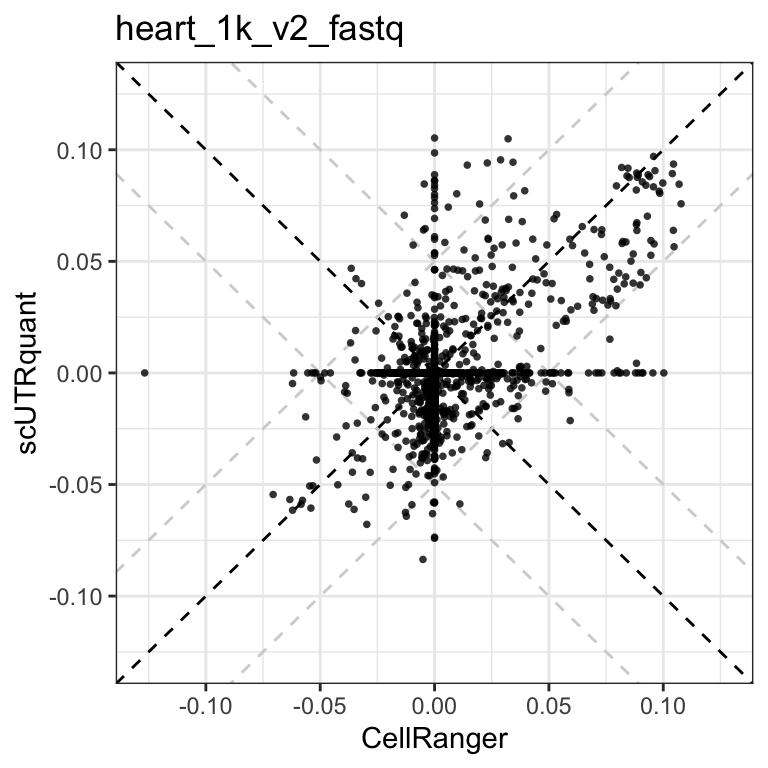

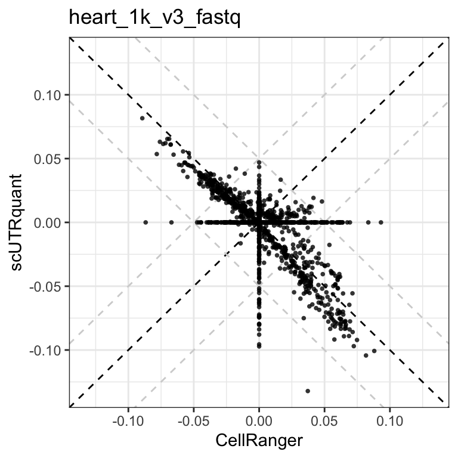

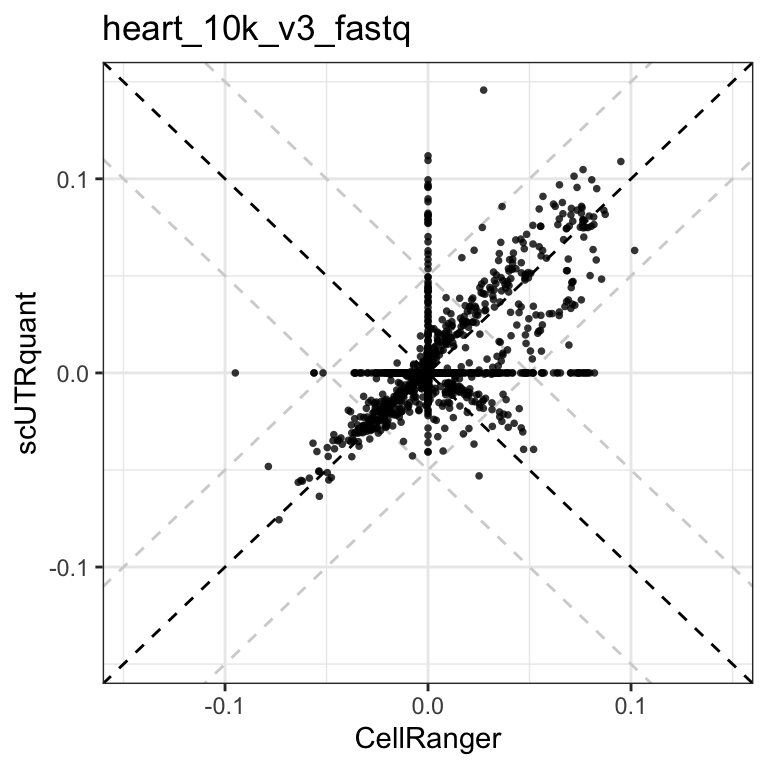

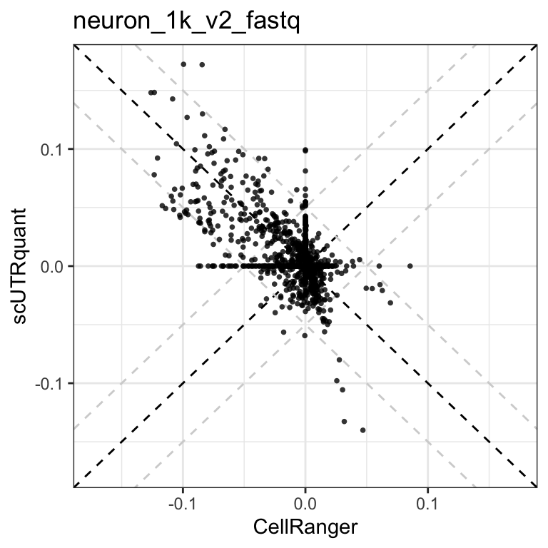

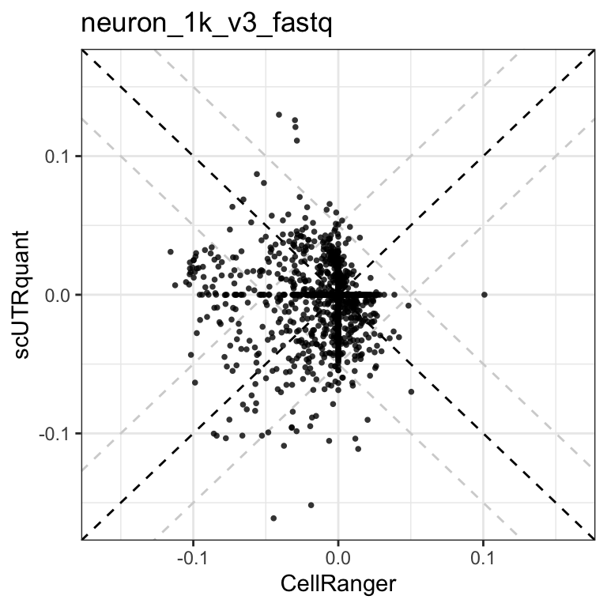

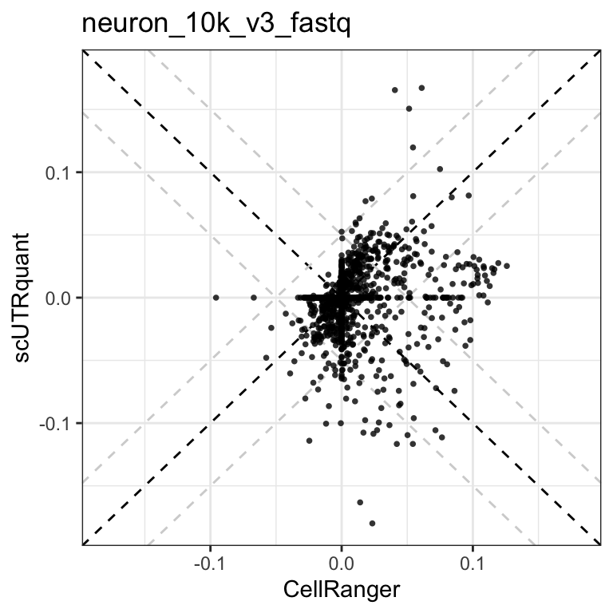

```r
df_pcs %>%
  transmute(sample_id, g=map(PC2, plot_weights_compare)) %>%
  deframe() %>% {
    for (id in names(.)) {
      ## print locally in this document
      print(.[[id]] + ggtitle(id))

      ## save to PDFs
      # ggsave(sprintf("output/supplement/sup2-pca-compare-%s.pdf", id),
      #        .[[id]], width=5, height=4, dpi=300)
    }
  }
```

# Conclusion

There are major discrepancies in the PC weightings, especially in the neuronal data. We need to dig deeper into which genes have very large differences.

# Runtime Details

## Conda Environment

[output not shown]

[output cut: 432 more lines]

[output not shown]